# IE425 - Spring 2022, Homework 2

Ahmet Yiğit Doğan - 2018402105

16 April, 2022

```r
# Library imports

library(data.table)
library(dplyr)
library(rpart)
library(caret)
library(randomForest)
library(gbm)
library(caTools)
library(Metrics)
library(ggcorrplot)

# Setting the working directory

setwd(getwd())

# Fixing the seed to 425

seed <- 425
```

# Question 1

Consider the “Human Resources Analytics” problem which is based on the data set “HR.csv”. Why are our best and most experienced employees leaving prematurely? Have fun with this database and try to predict which valuable employees will leave next. Fields in the data set include:

- Satisfaction Level
- Last evaluation
- Number of projects
- Average monthly hours
- Time spent at the company
- Whether they have had a work accident
- Whether they have had a promotion in the last 5 years
- Departments (the column “sales”)
- Salary
- Whether the employee has left

Our goal is to predict the profile of employees who are likely to quit.

```r
# Importing, modifying, and checking the data

hr                          <-  fread("HR.csv")

hr$Work_accident            <-  as.factor(hr$Work_accident)
hr$left                     <-  as.factor(hr$left)
hr$promotion_last_5years    <-  as.factor(hr$promotion_last_5years)
hr$sales                    <-  as.factor(hr$sales)
hr$salary                   <-  as.factor(hr$salary)

str(hr)
```

```
Classes ‘data.table’ and 'data.frame':  14999 obs. of  10 variables:
 $ satisfaction_level   : num  0.38 0.8 0.11 0.72 0.37 0.41 0.1 0.92 0.89 0.42 ...
 $ last_evaluation      : num  0.53 0.86 0.88 0.87 0.52 0.5 0.77 0.85 1 0.53 ...
 $ number_project       : int  2 5 7 5 2 2 6 5 5 2 ...
 $ average_montly_hours : int  157 262 272 223 159 153 247 259 224 142 ...
 $ time_spend_company   : int  3 6 4 5 3 3 4 5 5 3 ...
 $ Work_accident        : Factor w/ 2 levels "0","1": 1 1 1 1 1 1 1 1 1 1 ...
 $ left                 : Factor w/ 2 levels "0","1": 2 2 2 2 2 2 2 2 2 2 ...
 $ promotion_last_5years: Factor w/ 2 levels "0","1": 1 1 1 1 1 1 1 1 1 1 ...
 $ sales                : Factor w/ 10 levels "accounting","hr",..: 8 8 8 8 8 8 8 8 8 8 ...
 $ salary               : Factor w/ 3 levels "high","low","medium": 2 3 3 2 2 2 2 2 2 2 ...
 - attr(*, ".internal.selfref")=<externalptr>
```

## Part A

Partition the data set into training and test sets with 80% going into the training set by using a seed value of 425. Whenever you need to use the “set.seed” function, use set.seed(425).

```r
# Partitioning into training and test sets

set.seed(seed)

split1  <- sample.split(hr$left,
                        SplitRatio = 0.80)

hrtrain <- subset(hr, split1 == TRUE)
hrtest  <- subset(hr, split1 == FALSE)
```

## Part B

Determine the best random forest (based on the random forest package) by using 10-fold cross validation five times with the caret package on the training set by playing with the “mtry” and “ntree” parameters. What are the best values of these two parameters and what is the out-of-bag accuracy? Comment on which input attributes are important in making predictions.

```r
# Creating an empty data frame for the reporting after the trials

report1b            <- data.frame(matrix(ncol = 3, nrow = 0))

# Creating the tune grid with different mtry values:
# from the square root of total predictors to the total number of predictors

hr.rf.tuneGrid      <- expand.grid(mtry = (sqrt(ncol(hrtrain)-1) : (ncol(hrtrain)-1)))

# Generating trials for different number of trees

for(ntree in seq(from = 200, to = 800, by = 100)){

    set.seed(seed)

    try             <- train(left~.,
                             data       = hrtrain,
                             method     = "rf",
                             trControl  = trainControl(method   = 'repeatedcv',
                                                        number  = 10,
                                                        repeats = 5),
                             ntree      = ntree,
                             tuneGrid   = hr.rf.tuneGrid)

    temp            <- data.frame(ntree,
                                  try[["bestTune"]][["mtry"]],
                                  max(try[["results"]][["Accuracy"]]))

    report1b        <- rbind(report1b, temp)

}

# Displaying the report

colnames(report1b)  <- c("ntree", "Best mtry", "Accuracy")

report1b
```

| ntree | Best mtry | Accuracy |
| --- | --- | --- |
| 200 | 8 | 0.9907490 |
| 300 | 8 | 0.9908323 |
| 400 | 8 | 0.9908156 |
| 500 | 7 | 0.9907823 |
| 600 | 7 | 0.9908157 |
| 700 | 7 | 0.9908490 |
| 800 | 8 | 0.9908490 |

As the above table suggests, the best values for *“mtry”* and *“ntree”* are *7* and *700*, respectively, which yield an accuracy of *0.990849*.

Note that accuracy is fixed to its maximum value from a certain point on, implying that simply the higher values “ntree” takes the better the model gets in most cases since there is no risk of overfitting in the random forest algorithm.

```r
# Generating the best model

set.seed(seed)

hr.rf.best      <- train(left~.,
                         data       = hrtrain,
                         method     = "rf",
                         trControl  = trainControl(method   = 'repeatedcv',
                                                   number   = 10,
                                                   repeats  = 5),
                         # Choosing the best ntree value in terms of accuracy
                         ntree      = report1b[which.max(report1b$accuracy), "ntree"],
                         tuneGrid   = hr.rf.tuneGrid)

# Checking the best model, and its out-of-bag accuracy

hr.rf.best[["finalModel"]]
```

```
Call:
 randomForest(x = x, y = y, ntree = ..1, mtry = min(param$mtry,      ncol(x)))
               Type of random forest: classification
                     Number of trees: 700
No. of variables tried at each split: 7

        OOB estimate of  error rate: 0.84%
Confusion matrix:
     0    1 class.error
0 9124   18 0.001968935
1   83 2774 0.029051453
```

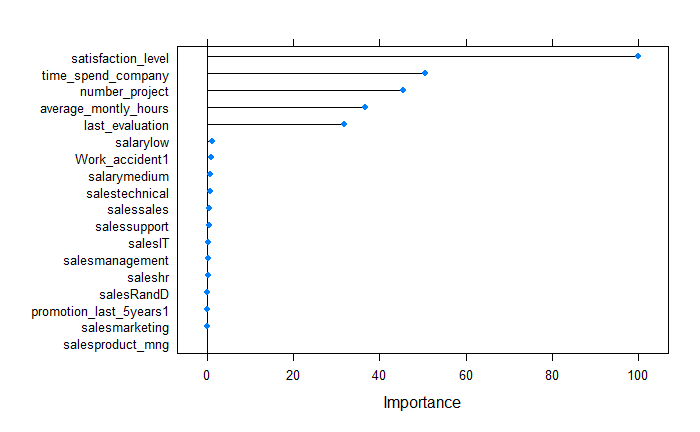

```r
# Checking the importance of the predictors

hr.rf.var.imp <- varImp(hr.rf.best)
plot(hr.rf.var.imp)
```

As the above plot suggests, 5 of the predictors have significantly high effect on the decisions of the employees:

- Satisfaction level
- Time spent in the company
- Number of projects
- Average monthly hours
- Last evaluation

Satisfaction level appears as a major decision criteria, which has an approximately double importance level of the second most important criteria, time spent in the company.

## Part C

Provide the Confusion Matrix along with sensitivity, specificity, precision and recall on the test set obtained by the best random forest.

```r
# Checking the confusion matrix associated with the best model

pred.hr.rf <- predict(hr.rf.best,
                      newdata = hrtest)

confusionMatrix(pred.hr.rf,
                hrtest$left,
                mode        = "everything",
                positive    = "1")
```

```
Confusion Matrix and Statistics

          Reference
Prediction    0    1
         0 2283   19
         1    3  695

               Accuracy : 0.9927
                 95% CI : (0.9889, 0.9954)
    No Information Rate : 0.762
    P-Value [Acc > NIR] : < 2.2e-16

                  Kappa : 0.9796

 Mcnemar's Test P-Value : 0.001384

            Sensitivity : 0.9734
            Specificity : 0.9987
         Pos Pred Value : 0.9957
         Neg Pred Value : 0.9917
              Precision : 0.9957
                 Recall : 0.9734
                     F1 : 0.9844
             Prevalence : 0.2380
         Detection Rate : 0.2317
   Detection Prevalence : 0.2327
      Balanced Accuracy : 0.9860

       'Positive' Class : 1
```

## Part D

Repeat part b with the gradient boosting using the “caret” and “gbm” packages by playing with the “interaction.depth”, “n.trees”, “shrinkage”, and “n.minobsinnode” parameters. What are the best values of these four parameters?

```r
hr.gbm.tuneGrid <- expand.grid(interaction.depth    = c(1, 2, 3),
                               n.trees              = c(200, 300, 400),
                               shrinkage            = (1:10)*0.1,
                               n.minobsinnode       = c(10, 15))

set.seed(seed)

hr.gbm <- train(left~.,
                data        = hrtrain,
                method      = "gbm",
                verbose     = FALSE,
                trControl   = trainControl(method   = 'repeatedcv',
                                           number   = 10,
                                           repeats  = 5),
                tuneGrid    = hr.gbm.tuneGrid)
```

Since the training set is large in this model, the shrinkage parameter is set to 0.1 due to performance issues. Besides the stump (1), 2 additional values are tested for the interaction depth. The best values for the 4 tuning parameters are as following:

- Interaction Depth: 3
- Number of Trees: 400
- Shrinkage (Learning Rate): 0.4
- The Minimum Observations in a Node: 15

## Part E

Provide the Confusion Matrix along with sensitivity, specificity, precision and recall on the test set obtained by the best boosting tree.

```r
# Checking the confusion matrix

pred.hr.gbm <- predict(hr.gbm,
                       newdata = hrtest)

confusionMatrix(pred.hr.gbm,
                hrtest$left,
                mode        = "everything",
                positive    = "1")
```

```
Confusion Matrix and Statistics

          Reference
Prediction    0    1
         0 2266   34
         1   20  680

               Accuracy : 0.982
                 95% CI : (0.9766, 0.9864)
    No Information Rate : 0.762
    P-Value [Acc > NIR] : < 2e-16

                  Kappa : 0.95

 Mcnemar's Test P-Value : 0.07688

            Sensitivity : 0.9524
            Specificity : 0.9913
         Pos Pred Value : 0.9714
         Neg Pred Value : 0.9852
              Precision : 0.9714
                 Recall : 0.9524
                     F1 : 0.9618
             Prevalence : 0.2380
         Detection Rate : 0.2267
   Detection Prevalence : 0.2333
      Balanced Accuracy : 0.9718

       'Positive' Class : 1
```

# Question 2

Consider the data set given in the file “ToyotaCorolla.csv”. The output attribute to be predicted is the Price attribute. Use a seed value of 425 wherever you need a seed.

```r
# Importing the data

tc <- fread("ToyotaCorolla.csv")
```

## Part A

Partition the data set into training and test sets where 80% of goes into the training set and 20% goes into the test set.

```r
set.seed(seed)

split2  <- sample.split(tc$Price,
                        SplitRatio = 0.80)

tctrain <- subset(tc, split2 == TRUE)
tctest  <- subset(tc, split2 == FALSE)
```

## Part B

Determine the best random forest (based on the random forest package) by using 10-fold cross validation five times with the caret package on the training set by playing with the "mtry" and "ntree" parameters. What are the best values of these two parameters and what is the out-of-bag accuracy? Comment on which input attributes are important in making predictions.

```r
# Creating an empty data frame for the reporting after the trials

report2b            <- data.frame(matrix(ncol = 3, nrow = 0))

# Creating the tune grid with different mtry values:
# from the square root of total predictors to the total number of predictors

tc.rf.tuneGrid      <- expand.grid(mtry = (sqrt(ncol(tctrain)-1) : (ncol(tctrain)-1)))

# Generating trials for different number of trees

for(ntree in seq(from = 200, to = 800, by = 100)){

    set.seed(seed)

    try             <- train(Price~.,
                             data       = tctrain,
                             method     = "rf",
                             trControl  = trainControl(method   = 'repeatedcv',
                                                       number   = 10,
                                                       repeats  = 5),
                             ntree      = ntree,
                             tuneGrid   = tc.rf.tuneGrid)

    temp            <- data.frame(ntree,
                                  try[["bestTune"]][["mtry"]],
                                  min(try[["results"]][["RMSE"]]))

    report2b        <- rbind(report2b, temp)

}

# Displaying the report

colnames(report2b)  <- c("ntree", "Best mtry", "RMSE")

report2b
```

| ntree | Best mtry | RMSE |
| --- | --- | --- |
| 200 | 5 | 1070.644 |
| 300 | 5 | 1069.000 |
| 400 | 5 | 1068.669 |
| 500 | 5 | 1069.013 |
| 600 | 5 | 1068.888 |
| 700 | 5 | 1069.052 |
| 800 | 5 | 1068.904 |

As the above table suggests, the best values for *“mtry”* and *“ntree”* are *5* and *400*, respectively, which yield an RMSE of *1068.6685083*.

```r
# Generating the best model

set.seed(seed)

tc.rf.best      <- train(   Price~.,
                            data        = tctrain,
                            method      = "rf",
                            trControl   = trainControl( method   = 'repeatedcv',
                                                        number   = 10,
                                                        repeats  = 5),
                            # Choosing the best ntree value in terms of accuracy
                            ntree       = report2b[which.min(report2b$rmse),"ntree"],
                            tuneGrid    = tc.rf.tuneGrid)

# Checking the best model, and its out-of-bag error
# (denoted as "Mean of squared residuals" in the output)

tc.rf.best[["finalModel"]]
```

```
Call:
 randomForest(x = x, y = y, ntree = ..1, mtry = min(param$mtry,      ncol(x)))
               Type of random forest: regression
                     Number of trees: 400
No. of variables tried at each split: 5

          Mean of squared residuals: 1128966
                    % Var explained: 91.8
```

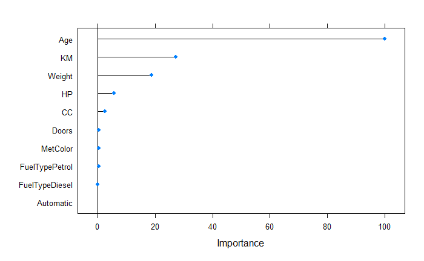

```r
# Checking the importance of the predictors

tc.rf.var.imp <- varImp(tc.rf.best)
plot(tc.rf.var.imp)
```

As can be seen in the above plot, age is the most important predictor by far. KM, Weight, HP and CC have also considerable effect on prices.

## Part C

Make predictions in the test set and report the root mean square error rate and mean absolute error using the functions in the Metrics package.

```r
# Making predictions in the test set

pred.tc.rf <- predict(tc.rf.best,
                      newdata = tctest)

# Reporting MAE

mae(actual      = tctest$Price,
    predicted   = pred.tc.rf)
```

```
[1] 767.2792
```

## Part D

Repeat part b with the gradient boosting using the “caret” and “gbm” packages by playing with the “interaction.depth”, “n.trees”, “shrinkage”, and “n.minobsinnode” parameters. What are the best values of these four parameters?

```r
tc.gbm.tuneGrid <- expand.grid(interaction.depth = c(1, 2, 3),
                               n.trees           = c(200, 300, 400),
                               shrinkage         = (1:10)*0.01,
                               n.minobsinnode    = c(10, 15))

set.seed(seed)

tc.gbm <- train(Price~.,
                data        = tctrain,
                method      = "gbm",
                verbose     = FALSE,
                trControl   = trainControl(method     = 'repeatedcv',
                                           number     = 10,
                                           repeats    = 5),
                tuneGrid    = tc.gbm.tuneGrid)
```

Since the training set is small this time, the shrinkage parameter is set to 0.01, which makes the model learn slower, and consequently better. Besides the stump (1), 2 additional values are tested for the interaction depth. The best values for the 4 tuning parameters are as following:

- Interaction Depth: 3
- Number of Trees: 400
- Shrinkage (Learning Rate): 0.05
- The Minimum Observations in a Node: 10

## Part E

Make predictions in the test set and report the root mean square error rate and mean absolute error using the functions in the “Metrics” package.

```r
# Making predictions in the test set

pred.tc.gbm <- predict(tc.gbm,
                       newdata = tctest)

# Reporting MAE

mae(actual      = tctest$Price,
    predicted   = pred.tc.gbm)
```

```
[1] 801.9213
```

# Resources

- [Tune Machine Learning Algorithms in R (random forest case study)](https://machinelearningmastery.com/tune-machine-learning-algorithms-in-r/)
- [Hands on Machine Learning with R - Chapter 12: Gradient Boosting](https://bradleyboehmke.github.io/HOML/gbm.html#xgboost)
- [GBM (Boosted Models) Tuning Parameters](https://www.listendata.com/2015/07/gbm-boosted-models-tuning-parameters.html)
- [Setting values for ntree and mtry for random forest regression model](https://stackoverflow.com/questions/13956435/setting-values-for-ntree-and-mtry-for-random-forest-regression-model)